# Multilevel Modeling

Opioid overdose emergency department visits in Virginia counties.

Faysal Shaikh

Last updated April 29, 2024

```r
library(tidyverse)
library(readxl)
library(sf)
library(broom)
library(nlme)
# library(lme4)
# library(stringr)
# library(forecast)
```

# Data Sources

We are using [VDH county opioid overdose emergency department (ED) visits](https://www.vdh.virginia.gov/surveillance-and-investigation/syndromic-surveillance/drug-overdose-surveillance/) data sources as our outcomes data.

To further contextualize county opioid overdose ED visits, we also examine annual population estimates for Virginia counties as produced by the [UVA Weldon Cooper Center for Public Service](https://www.coopercenter.org/virginia-population-estimates).

We also include geographic data in a shapefile of 2023 Virginia Administrative Boundaries [obtained from the Virginia Geographic Information Network](https://vgin.vdem.virginia.gov/datasets/777890ecdb634d18a02eec604db522c6/about) for later use in exploratory chloropleth mapping. This shapefile visually represents adjacent counties, but is not by itself in a form accessible to code and implement spatial autocorrelation in our modeling. Thus, we utilize the [2023 Census Bureau County Adjacency File](https://www.census.gov/geographies/reference-files/time-series/geo/county-adjacency.html) for this purpose (though we are only interested in Virginia counties).

For relevant additional covariates and predictor measures of interest, we utilize the [County Health Rankings & Roadmaps dataset](https://www.countyhealthrankings.org/health-data/methodology-and-sources/data-documentation/national-data-documentation-2010-2022).

We handle project directory and data source filepath specification immediately below, before performing data exploration on our 2 major data sources separately in the proceeding sections. Notably, we also handle data source filepath specification for the aforementioned geographic data.

```r
# path specification: data directory
data_dir_path <- # uncomment appropriate option below
    "d:/Codebase/ms-thesis/data/" # laptop
    # "f:/Codebase/ms-thesis/data/" # desktop

# filename specification: Virginia administrative boundaries shapefiles
va_admin_bound_fname <-
    "VirginiaAdministrativeBoundary.shp/VirginiaCounty.shp"

# filename specification: US County Adjacency File
county_adjacency_fname <-
    "county_adjacency2023.txt"

# filename specification: overdose ED visits
vdh_ed_visits_fname <-
    "Drug-Overdose-ED-Visits_Virginia-January-2024.xlsx"

# filename specification: county population estimates
va_popest_2010_2020_fname <-
    "VA-Intercensal-Estimates_2010-2020_UVA-CooperCenter_Updated-2023-01.xlsx"
va_popest_2020_2023_fname <-
    "VA-Intercensal-Estimates_2020-2023_UVA-CooperCenter.xlsx"

# filename specification: County Health Rankings & Roadmaps ("CHR") data
chr_fnames <- list(
    "2015" = "2015 County Health Rankings Virginia Data - v3.xls",
    "2016" = "2016 County Health Rankings Virginia Data - v3.xls",
    "2017" = "2017 County Health Rankings Virginia Data - v2.xls",
    "2018" = "2018 County Health Rankings Virginia Data - v3.xls",
    "2019" = "2019 County Health Rankings Virginia Data - v1_0.xls",
    "2020" = "2020 County Health Rankings Virginia Data - v1_0.xlsx",
    "2021" = "2021 County Health Rankings Virginia Data - v1_0.xlsx",
    "2022" = "2022 County Health Rankings Virginia Data - v2.xlsx",
    "2023" = "2023 County Health Rankings Virginia Data - v3.xlsx"
)
```

## Geography of Virginia Counties

This project examines data on Virginia counties as the primary units of analysis. As a geographic reference, we include below a labeled map of Virginia counties obtained from [the Virginia Association of Counties (VACO) website](https://www.vaco.org/about/regions/):

[figure not shown]

### Virginia counties shapefile

Similarly, we generate our own map of Virginia counties and county-equivalents via the previously mentioned 2023 Virginia Administrative Boundaries shapefile, visualized without additional data below:

```r
va_counties <- # read shapefile
    st_read(paste0(data_dir_path, va_admin_bound_fname)) %>%
    mutate(NAMELSAD = str_to_upper(NAMELSAD)) # uppercase names to avoid
```

[figure not shown]

```r
                                              # capitalization merge conflicts

# plot geographic data
va_counties %>%
    ggplot() +
    geom_sf() +
    theme_void()
```

We will use this template as the basis for chloropleth exploratory data visualizations throughout this process.

## Opioid Overdose ED Visits in Virginia Counties

We utilize the Virginia Department of Health website to download data on unintentional drug overdose. Data are in the form of a Microsoft Excel workbook and are loaded-in via the below chunk:

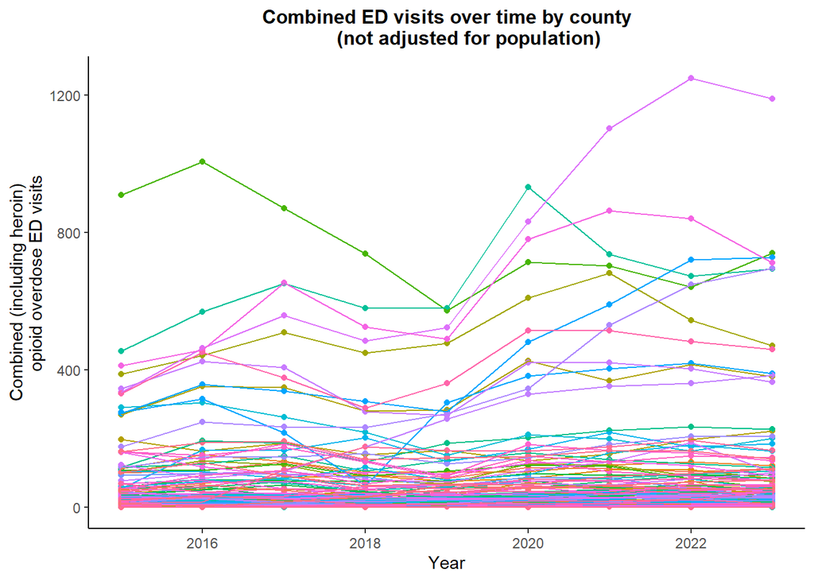

```r
# preparation for reading-in data: VDH opioid overdose ED visits
vdh_ed_visits_fullpath <-
    paste0(data_dir_path, vdh_ed_visits_fname) # precombine fname parts
vdh_ed_visits_sheetslist <-
    excel_sheets(vdh_ed_visits_fullpath) # get list of worksheet "tabs" for MS
                                         # Excel workbook file to mask for
                                         # specific sheet(s)

# reading-in data: VDH opioid overdose ED visits
vdh_ed_visits_nonheroin_opioid <- read_excel(
    path = vdh_ed_visits_fullpath,
    sheet = vdh_ed_visits_sheetslist[5] # locality opioid
) %>%
    slice(-1) # remove first non-data row

vdh_ed_visits_heroin <- read_excel(
    path = vdh_ed_visits_fullpath,
    sheet = vdh_ed_visits_sheetslist[6] # locality heroin
) %>%
    slice(-1) # remove first non-data row

## output data: nonheroin opioid ED visits
# want to deprecate this (dates_vec)
dates_vec <- # derived years date-vector for time masking (as-needed)
    2015:2023 %>%
    paste("Total") # Year "Total"

vdh_localities_df <- # derived data frame for geographic masking (as-needed)
    vdh_ed_visits_nonheroin_opioid %>%
    select("OPIOID", "...2") %>%
    rename("Locality" = "OPIOID", "FIPS" = "...2") %>%
    lapply(
        function(x) str_replace_all(x, "[^a-zA-Z0-9 ]", "") # remove special
                                                            # characters (i.e.,
                                                            # double-dagger)
    ) %>%
    as.data.frame() %>% # required to undo list-conversion following lapply
    mutate(Locality = str_to_upper(Locality)) # avoid name case issues for merge

nonheroin_wide <- # nonheroin opioid ED visits (wide format)
    vdh_localities_df %>%
    cbind(vdh_ed_visits_nonheroin_opioid[c(
        51 + (0:(2023 - 2015)) * 52, # indices for annual overdose visits
        54 + (0:(2023 - 2015)) * 52 # indices for annual avg monthly overdose
                                    # visits per 100K population
    )]) %>%
    mutate(across(-Locality, as.numeric)) %>% # convert non-labels to numeric
    rename_with(
        .fn = function(original_colname) {
            # extract number from colname
            original_colname_num <- original_colname %>%
                substr(., 4, nchar(.)) %>% # remove leading "..."
                as.numeric()

            # transform number to year number, as a character type
            new_colname_num <-
                as.character(2015 + (original_colname_num - 54) / 52)

            new_colname <- paste(new_colname_num, "Avg Monthly Rate per 100K")

            return(new_colname)
        },
        .cols = 12:last_col() # only avg monthly cols
    )

nonheroin_opioid_edvisits_df <-
    nonheroin_wide %>%
    pivot_longer( # CREATES 2 COLS IN LONG FORMAT:
                  # - ANNUAL COUNT
                  # - ANNUAL AVG MONTHLY RATE PER 100K POPULATION
        cols = 3:last_col(), # want to ignore Locality & FIPS
        names_to = c("Year", ".value"),
        names_sep = " "
    ) %>%
    rename(
        "ed_visit_count" = "Total",
        "ed_visit_rate_per_100K" = "Avg"
    )

## output data: heroin (opioid) ED visits
heroin_wide <- # heroin ED visits (wide format)
    vdh_localities_df %>%
    cbind(vdh_ed_visits_heroin[c(
        51 + (0:(2023 - 2015)) * 52, # indices for annual overdose visits
        54 + (0:(2023 - 2015)) * 52 # indices for annual avg monthly overdose
                                    # visits per 100K population
    )]) %>%
    mutate(across(-Locality, as.numeric)) %>% # convert non-labels to numeric
    rename_with(
        .fn = function(original_colname) {
            # extract number from colname
            original_colname_num <- original_colname %>%
                substr(., 4, nchar(.)) %>% # remove leading "..."
                as.numeric()

            # transform number to year number, as a character type
            new_colname_num <-
                as.character(2015 + (original_colname_num - 54) / 52)

            new_colname <- paste(new_colname_num, "Avg Monthly Rate per 100K")

            return(new_colname)
        },
        .cols = 12:last_col() # only avg monthly cols
    )

heroin_edvisits_df <-
    heroin_wide %>%
    pivot_longer( # CREATES 2 COLS IN LONG FORMAT:
                  # - ANNUAL COUNT
                  # - ANNUAL AVG MONTHLY RATE PER 100K POPULATION
        cols = 3:last_col(), # want to ignore Locality & FIPS
        names_to = c("Year", ".value"),
        names_sep = " "
    ) %>%
    rename(
        "ed_visit_count" = "Total",
        "ed_visit_rate_per_100K" = "Avg"
    )

## output data: combined ED visits [heroin (opioid) + nonheroin opioid]
combined_edvisits_df <-
    inner_join(
        x = heroin_edvisits_df,
        y = nonheroin_opioid_edvisits_df,
        by = c("Locality", "FIPS", "Year"),
        suffix = c(".heroin", ".nonheroin_opioid")
    ) %>%
    group_by(Locality, Year) %>%
    mutate(
        FIPS = as.character(FIPS), # fix treatment of FIPS as double
        Year = as.numeric(Year),
        ed_visit_count.combined = sum(
            ed_visit_count.nonheroin_opioid,
            ed_visit_count.heroin
        ),
        ed_visit_rate_per_100K.combined = sum(
            ed_visit_rate_per_100K.nonheroin_opioid,
            ed_visit_rate_per_100K.heroin
        ),
        # annual ED visit rates per 100K population (12X of Avg-Monthly rates)
        ed_visit_rate_per_100K.combined_annual =
            12 * ed_visit_rate_per_100K.combined,
        ed_visit_rate_per_100K.nonheroin_opioid_annual =
            12 * ed_visit_rate_per_100K.nonheroin_opioid,
        ed_visit_rate_per_100K.heroin_annual =
            12 * ed_visit_rate_per_100K.heroin
    ) %>%
    left_join( # combine above with geography
        va_counties,
        by = c("Locality" = "NAMELSAD") # dplyr 1.0.8 syntax
    ) # after geographic join, I found an unexpected number of NA values. turns
      # out, many of these are due to NA values in the geographic column:
      # LASTUPDATE. other (expected) NA values were when Locality == "VIRGINIA"
      # (no assigned FIPS code in our county dataset for entire VA state entity)

# visualize combined ED visits
## Plot 1: Counts (not adjusted for population)
combined_edvisits_df %>%
    filter(Locality != "VIRGINIA") %>%
    ggplot(aes(
        x = Year,
        y = ed_visit_count.combined,
        color = Locality
        )
    ) +
    geom_point() +
    geom_line() +
    theme_classic() +
    theme(legend.position = "none") +
    ggtitle(
        "Combined ED visits over time by county
        (not adjusted for population)"
    ) +
    ylab(
        "Combined (including heroin)
        opioid overdose ED visits"
    ) +
    theme(plot.title = element_text(hjust = 0.5, size = 12, face = "bold"))
```

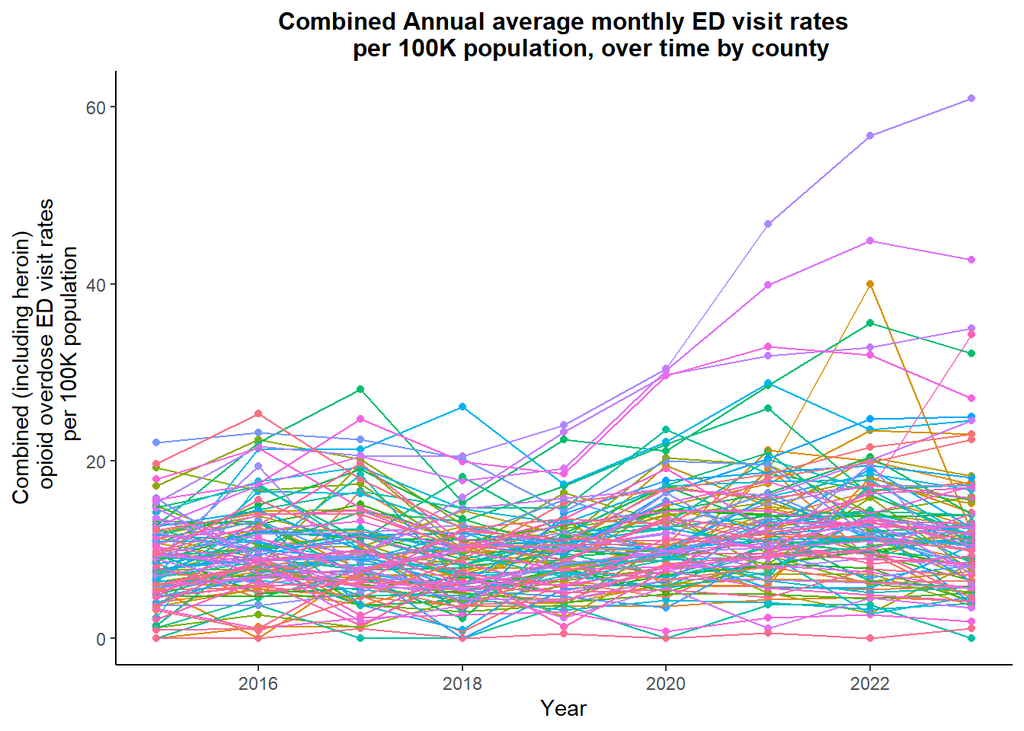

```r
## Plot 2: Annual Avg-Monthly-Rates-per-100K-Population
combined_edvisits_df %>%
    filter(Locality != "VIRGINIA") %>%
    ggplot(aes(
        x = Year,
        y = ed_visit_rate_per_100K.combined,
        color = Locality
        )
    ) +
    geom_point() +
    geom_line() +
    theme_classic() +
    theme(legend.position = "none") +
    ggtitle(
        "Combined Annual average monthly ED visit rates
        per 100K population, over time by county"
    ) +
    ylab(
        "Combined (including heroin)
        opioid overdose ED visit rates
        per 100K population"
    ) +
    theme(plot.title = element_text(hjust = 0.5, size = 12, face = "bold"))
```

```r
# # print data in wide format as an HTML table
# # BROKEN(?): double-check what "summarize_all(sum)" is doing
# combined_edvisits_df[, c(1, 3:9)] %>%
#     group_by(Locality, Year) %>%
#     summarize_all(sum) %>%
#     knitr::kable(style = "html")
```

According to VDH criteria, [opioid data seems to exclude “heroin”](https://www.vdh.virginia.gov/surveillance-and-investigation/syndromic-surveillance/drug-overdose-case-definition/#:~:text=medication%20or%20drug%2C-,heroin,-%2C%20dope%2C%20speed%20ball) ICD codes. Experts believe heroin opioid overdose deaths have plateaued in the wake of the latest wave(s) of the opioid epidemic, driven now heavily by synthetic opioids such as fentanyl.

However, our preliminary exploratory data analysis shows that heroin overdose ED visits in fact continue to contribute to the overall trends in opioid overdose ED visits, so we explore opioid overdose ED visits for all opioids including heroin.

## Population Estimates for Virginia Counties

We contextualize the county opioid overdose ED visits number with the county’s population by incorporating annual county population estimates from UVA’s Weldon Cooper Center for Public Service from 2015 to 2023. We first read-in the data below, before merging it with the ED visits data above (`combined_edvisits_df`).

```r
# preparation for reading-in data: VA county population estimates
va_popest_2010_2020_fullpath <-
    paste0(data_dir_path, va_popest_2010_2020_fname) # precombine fname parts
va_popest_2020_2023_fullpath <-
    paste0(data_dir_path, va_popest_2020_2023_fname) # precombine fname parts

# reading-in data: VA county population estimates
va_popest_2010_2020 <- read_excel(
    path = va_popest_2010_2020_fullpath,
    skip = 4 # start at county estimates
) %>%
    rename(
        idx = 1,
        Locality = 2,
        `2010_census` = 3
    ) %>%
    select(Locality, as.character(2010:2019)) %>%
    na.omit() %>%
    pivot_longer( # change from wide to long format
        cols = as.character(2010:2019),
        names_to = "Year",
        values_to = "annual_popest",
    ) %>%
    mutate(
        Locality = str_to_upper(Locality),
        Year = as.numeric(Year)
    )
va_popest_2020_2023 <- read_excel(
    path = va_popest_2020_2023_fullpath,
    skip = 4 # start at county estimates
) %>%
    rename(
        idx = 1,
        Locality = 2,
        `2020_census` = 3
    ) %>%
    select(Locality, as.character(2020:2023)) %>%
    na.omit() %>%
    pivot_longer( # change from wide to long format
        cols = as.character(2020:2023),
        names_to = "Year",
        values_to = "annual_popest",
    ) %>%
    mutate(
        Locality = str_to_upper(Locality),
        Year = as.numeric(Year)
    )
# merge 2010_2020 and 2020_2023 together (2010_2023)
va_popest_2010_2023 <- bind_rows(
    va_popest_2010_2020,
    va_popest_2020_2023
) %>%
    group_by(Locality)

# merge into combined_edvisits_df
combined_edvisits_df <- combined_edvisits_df %>%
    left_join(va_popest_2010_2023)
```

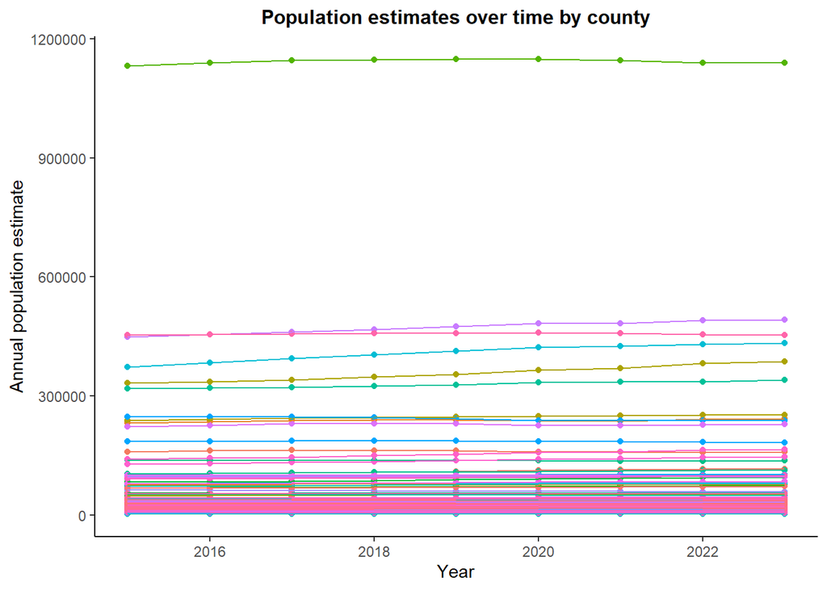

```r
# visualize popest values
combined_edvisits_df %>% # just exclude VA state this time
    filter(Locality != "VIRGINIA") %>%
    ggplot(aes(x = Year, y = annual_popest, color = Locality)) +
    geom_point() +
    geom_line() +
    theme_classic() +
    theme(legend.position = "none") +
    ggtitle("Population estimates over time by county") +
    ylab("Annual population estimate") +
    theme(plot.title = element_text(hjust = 0.5, size = 12, face = "bold"))
```

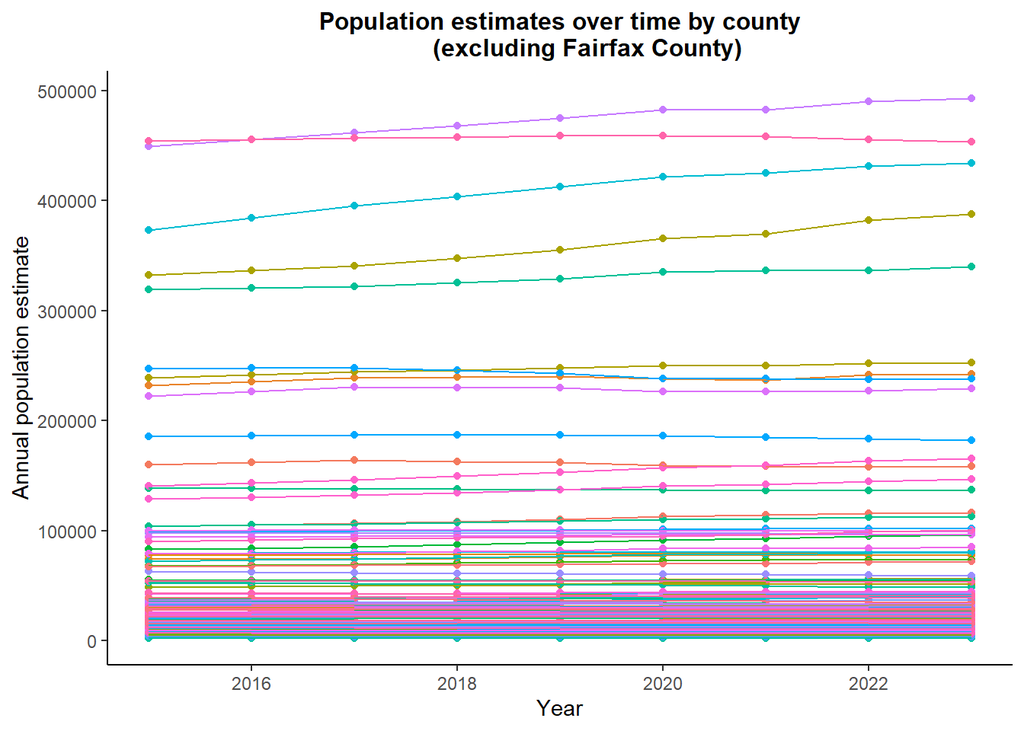

```r
combined_edvisits_df %>% # now exclude Fairfax County as well
    filter(! Locality %in%  c("VIRGINIA", "FAIRFAX COUNTY")) %>%
    ggplot(aes(x = Year, y = annual_popest, color = Locality)) +
    geom_point() +
    geom_line() +
    theme_classic() +
    theme(legend.position = "none") +
    ggtitle("Population estimates over time by county
        (excluding Fairfax County)") +
    ylab("Annual population estimate") +
    theme(plot.title = element_text(hjust = 0.5, size = 12, face = "bold"))
```

### Calculate opioid overdose ED visit rates per 100K

We use data from VDH for opioid overdose ED visits in conjunction with data from UVA population estimates to transform opioid overdose ED visit counts into rates per 100K population.

```r
# 04/29/2023: below is broken. favoring VDH numbers for rate per 100K population
# until other fixes are made to calculate appopriate entities together (based
# on VDH methodology, also described in Figure S1 of publication)
combined_edvisits_df <- combined_edvisits_df %>%
    mutate(
        combined_rate_per_100K = (combined / annual_popest) * (10**5),
        heroin_rate_per_100K = (heroin / annual_popest) * (10**5),
        nonheroin_opioid_rate_per_100K =
            (nonheroin_opioid / annual_popest) * (10**5)
    )

# print in wide format to HTML table
combined_edvisits_df %>%
    select(Locality, Year, combined_rate_per_100K) %>%
    pivot_wider(
        names_from = Year,
        values_from = combined_rate_per_100K
    ) %>%
    group_by(Locality) %>%
    summarize_all(sum) %>%
    knitr::kable(style = "html")

# visualize ED visit rate per 100K values
combined_edvisits_df %>%
    filter(Locality != "VIRGINIA") %>%
    ggplot(aes(x = Year, y = combined_rate_per_100K, color = Locality)) +
    geom_point() +
    geom_line() +
    theme_classic() +
    theme(legend.position = "none") +
    ggtitle("ED visit rates over time by county") +
    ylab("ED visit rates per 100K population") +
    theme(plot.title = element_text(hjust = 0.5, size = 12, face = "bold"))
```

[output not shown]

These opioid overdose ED visit rates per 100,000 population will serve as our primary outcome measure for our analyses.

## National County Health Rankings & Roadmaps Data

```r
chr_data_collector <- data.frame(
    Locality_shortname = character(),
    `Health Behaviors` = numeric(),
    `Clinical Care` = numeric(),
    `Social & Economic Factors` = numeric(),
    `Physical Environment` = numeric()
)

for (chosen_year in 2015:2023) {
    chosen_chr_fname <- chr_fnames[as.character(chosen_year)]
    chosen_chr_fullpath <- paste0(data_dir_path, chosen_chr_fname)
    chosen_chr_sheetslist <- excel_sheets(chosen_chr_fullpath)

    chosen_chr_raw_data <- read_excel(
        path = chosen_chr_fullpath,
        sheet = chosen_chr_sheetslist[3] # Outcomes & Factors SubRankings
    ) %>%
        select(
            `...1`,
            `Health Behaviors`,
            `Clinical Care`,
            `Social & Economic Factors`,
            `Physical Environment`
        ) %>%
        rename("FIPS" = `...1`) %>%
        slice(-1:-2) %>% # remove first 2 non-data rows
        mutate(
            "Year" = as.numeric(chosen_year),
            `Health Behaviors` = as.numeric(`Health Behaviors`),
            `Clinical Care` = as.numeric(`Clinical Care`),
            `Social & Economic Factors` =
                as.numeric(`Social & Economic Factors`),
            `Physical Environment` = as.numeric(`Physical Environment`)
        )

    chr_data_collector <- chr_data_collector %>%
        rbind(chosen_chr_raw_data)
}
```

Since there is so much data, we will merge in a separate chunk.

```r
combined_edvisits_df <- combined_edvisits_df %>%
    left_join(chr_data_collector, by = c("FIPS", "Year"))

combined_edvisits_df <-
    combined_edvisits_df %>% # need to be separate from above for some reason
    rename(
        "zHB" = "Health Behaviors",
        "zCC" = "Clinical Care",
        "zSEF" = "Social & Economic Factors",
        "zPE" = "Physical Environment"
    )
```

At this point, we have all relevant data collected into a single data frame, and we can proceed with our analyses.

# Multilevel Modeling

Some of our lesser-specified models will omit main/random effects of time (slopes) and also main effects of time-varying covariates.

## “Unconditional Growth” Model

Our first model, referred to as an “Unconditional Growth” model, consists of main and random effects for intercept, but nothing else.

```r
# # model 1 with counts
# model_1_counts <- combined_edvisits_df %>%
#     filter(Locality != "VIRGINIA") %>%
#     filter(Year %in% 2016:2021) %>% # match w/ publication
#     lme( # nlme implementation
#         fixed = ed_visit_count.nonheroin_opioid ~ 1,
#         random = ~ 1 | Locality
#     )
#     # lmer( # lme4 implementation
#     #     formula = ed_visit_count.combined ~ (1 | Locality)
#     # )

# summary(model_1_counts)

# model 1 with rates
model_1_rates <- combined_edvisits_df %>%
    filter(Locality != "VIRGINIA") %>%
    # filter(Year %in% 2016:2021) %>% # match w/ publication
    lme( # nlme implementation
        fixed = ed_visit_rate_per_100K.combined_annual ~
            1,
        random = ~ 1 | Locality
    )
    # lmer( # lme4 implementation
    #     formula = ed_visit_rate_per_100K.combined ~ (1 | Locality),
    # )

summary(model_1_rates)
```

```
## Linear mixed-effects model fit by REML
##   Data: .
##        AIC      BIC    logLik
##   13333.89 13349.15 -6663.947
##
## Random effects:
##  Formula: ~1 | Locality
##         (Intercept) Residual
## StdDev:    60.88841 55.32904
##
## Fixed effects:  ed_visit_rate_per_100K.combined_annual ~ 1
##                Value Std.Error   DF  t-value p-value
## (Intercept) 134.6687   5.51658 1064 24.41162       0
##
## Standardized Within-Group Residuals:
##         Min          Q1         Med          Q3         Max
## -3.44064978 -0.46755673 -0.06183324  0.42633453  6.46224382
##
## Number of Observations: 1197
## Number of Groups: 133
```

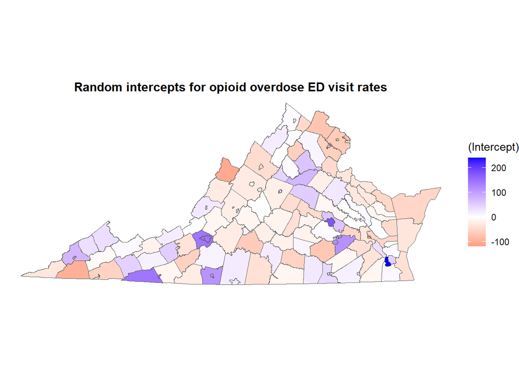

```r
# ranef(model_1_counts) %>%
#     rownames_to_column(var = "Locality") %>%
#     left_join( # combine above with geography
#         va_counties,
#         by = c("Locality" = "NAMELSAD") # dplyr 1.0.8 syntax
#     ) %>%
#     ggplot() +
#     geom_sf(aes(fill = `(Intercept)`, geometry = geometry)) +
#     scale_fill_gradient2( # ggplot2 3.3.5 syntax
#         midpoint = 0,
#         high = "blue",
#         mid = "white",
#         low = "red",
#         na.value = "black",
#         guide = "colorbar"
#     ) +
#     theme_void() +
#     ggtitle("Random intercepts for opioid overdose ED visit counts") +
#     theme(plot.title = element_text(hjust = 0.5, size = 12, face = "bold"))


ranef(model_1_rates) %>%
    rownames_to_column(var = "Locality") %>%
    left_join( # combine above with geography
        va_counties,
        by = c("Locality" = "NAMELSAD") # dplyr 1.0.8 syntax
    ) %>%
    ggplot() +
    geom_sf(aes(fill = `(Intercept)`, geometry = geometry)) +
    scale_fill_gradient2( # ggplot2 3.3.5 syntax
        midpoint = 0,
        high = "blue",
        mid = "white",
        low = "red",
        na.value = "black",
        guide = "colorbar"
    ) +
    theme_void() +
    ggtitle("Random intercepts for opioid overdose ED visit rates") +
    theme(plot.title = element_text(hjust = 0.5, size = 12, face = "bold"))
```

## “Fixed Growth” Model

Our second model, referred to as a “Fixed Growth” model, consists of main and random effects for intercept but only a main effect of time.

```r
# # model 2 with counts
# model_2_counts <- combined_edvisits_df %>%
#     filter(Locality != "VIRGINIA") %>%
#     filter(Year %in% 2016:2021) %>% # match w/ publication
#     mutate(Year.adj = Year - 2015) %>% # for interpretation
#     lme(
#         fixed = ed_visit_count.nonheroin_opioid ~ Year.adj,
#         random = ~ 1 | Locality
#     )

# summary(model_2_counts)

# model 2 with rates
model_2_rates <- combined_edvisits_df %>%
    filter(Locality != "VIRGINIA") %>%
    # filter(Year %in% 2016:2021) %>% # match w/ publication
    mutate(Year.adj = Year - 2015) %>% # for interpretation
    lme(
        fixed = ed_visit_rate_per_100K.combined_annual ~
            Year.adj,
        random = ~ 1 | Locality
    )

summary(model_2_rates)
```

```
## Linear mixed-effects model fit by REML
##   Data: .
##        AIC      BIC   logLik
##   13159.58 13179.92 -6575.79
##
## Random effects:
##  Formula: ~1 | Locality
##         (Intercept) Residual
## StdDev:    61.30968 50.97062
##
## Fixed effects:  ed_visit_rate_per_100K.combined_annual ~ Year.adj
##                 Value Std.Error   DF  t-value p-value
## (Intercept) 103.14756  5.970066 1063 17.27746       0
## Year.adj      7.88028  0.570583 1063 13.81093       0
##  Correlation:
##          (Intr)
## Year.adj -0.382
##
## Standardized Within-Group Residuals:
##         Min          Q1         Med          Q3         Max
## -3.18173222 -0.53111635 -0.05014445  0.43798970  6.33110904
##
## Number of Observations: 1197
## Number of Groups: 133
```

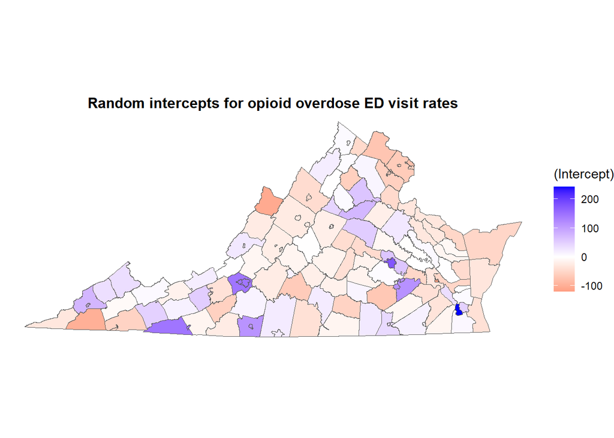

```r
# ranef(model_2_counts) %>%
#     rownames_to_column(var = "Locality") %>%
#     left_join( # combine above with geography
#         va_counties,
#         by = c("Locality" = "NAMELSAD") # dplyr 1.0.8 syntax
#     ) %>%
#     ggplot() +
#     geom_sf(aes(fill = `(Intercept)`, geometry = geometry)) +
#     scale_fill_gradient2( # ggplot2 3.3.5 syntax
#         midpoint = 0,
#         high = "blue",
#         mid = "white",
#         low = "red",
#         na.value = "black",
#         guide = "colorbar"
#     ) +
#     theme_void() +
#     ggtitle("Random intercepts for opioid overdose ED visit counts") +
#     theme(plot.title = element_text(hjust = 0.5, size = 12, face = "bold"))

ranef(model_2_rates) %>%
    rownames_to_column(var = "Locality") %>%
    left_join( # combine above with geography
        va_counties,
        by = c("Locality" = "NAMELSAD") # dplyr 1.0.8 syntax
    ) %>%
    ggplot() +
    geom_sf(aes(fill = `(Intercept)`, geometry = geometry)) +
    scale_fill_gradient2( # ggplot2 3.3.5 syntax
        midpoint = 0,
        high = "blue",
        mid = "white",
        low = "red",
        na.value = "black",
        guide = "colorbar"
    ) +
    theme_void() +
    ggtitle("Random intercepts for opioid overdose ED visit rates") +
    theme(plot.title = element_text(hjust = 0.5, size = 12, face = "bold"))
```

## “Random Growth” Model

Our third model, referred to as a “Random Growth” model, consists of main and random effects for both intercept and time.

```r
# # model 3 with counts
# model_3_counts <- combined_edvisits_df %>%
#     filter(Locality != "VIRGINIA") %>%
#     filter(Year %in% 2016:2021) %>% # match w/ publication
#     mutate(Year.adj = Year - 2015) %>% # for interpretation
#     lme(
#         fixed = ed_visit_count.nonheroin_opioid ~ Year.adj,
#         random = ~ Year.adj | Locality
#     )

# summary(model_3_counts)

# model 3 with rates
model_3_rates <- combined_edvisits_df %>%
    filter(Locality != "VIRGINIA") %>%
    # filter(Year %in% 2016:2021) %>% # match w/ publication
    mutate(Year.adj = Year - 2015) %>% # for interpretation
    lme(
        fixed = ed_visit_rate_per_100K.combined_annual ~
            Year.adj,
        random = ~ Year.adj | Locality
    )

summary(model_3_rates)
```

```
## Linear mixed-effects model fit by REML
##   Data: .
##        AIC      BIC    logLik
##   12742.08 12772.59 -6365.039
##
## Random effects:
##  Formula: ~Year.adj | Locality
##  Structure: General positive-definite, Log-Cholesky parametrization
##             StdDev   Corr
## (Intercept) 47.30395 (Intr)
## Year.adj    12.45933 -0.177
## Residual    37.96590
##
## Fixed effects:  ed_visit_rate_per_100K.combined_annual ~ Year.adj
##                 Value Std.Error   DF   t-value p-value
## (Intercept) 103.14756  4.573704 1063 22.552302       0
## Year.adj      7.88028  1.160951 1063  6.787777       0
##  Correlation:
##          (Intr)
## Year.adj -0.284
##
## Standardized Within-Group Residuals:
##         Min          Q1         Med          Q3         Max
## -3.18014996 -0.50400332 -0.01639559  0.45345845  6.42376604
##
## Number of Observations: 1197
## Number of Groups: 133
```

### Plot model outputs

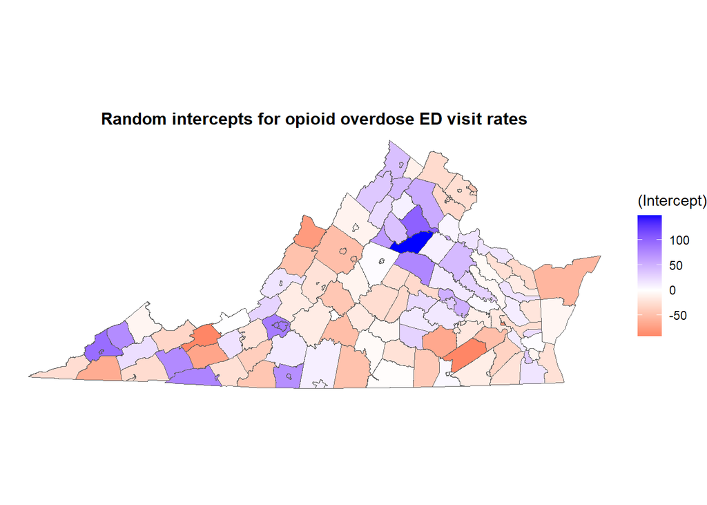

```r
# ranef(model_3_counts) %>%
#     rownames_to_column(var = "Locality") %>%
#     left_join( # combine above with geography
#         va_counties,
#         by = c("Locality" = "NAMELSAD") # dplyr 1.0.8 syntax
#     ) %>%
#     ggplot() +
#     geom_sf(aes(fill = `(Intercept)`, geometry = geometry)) +
#     scale_fill_gradient2( # ggplot2 3.3.5 syntax
#         midpoint = 0,
#         high = "blue",
#         mid = "white",
#         low = "red",
#         na.value = "black",
#         guide = "colorbar"
#     ) +
#     theme_void() +
#     ggtitle("Random intercepts for opioid overdose ED visit counts") +
#     theme(plot.title = element_text(hjust = 0.5, size = 12, face = "bold"))

# ranef(model_3_counts) %>%
#     rownames_to_column(var = "Locality") %>%
#     left_join( # combine above with geography
#         va_counties,
#         by = c("Locality" = "NAMELSAD") # dplyr 1.0.8 syntax
#     ) %>%
#     ggplot() +
#     geom_sf(aes(fill = `Year.adj`, geometry = geometry)) +
#     scale_fill_gradient2( # ggplot2 3.3.5 syntax
#         midpoint = 0,
#         high = "blue",
#         mid = "white",
#         low = "red",
#         na.value = "black",
#         guide = "colorbar"
#     ) +
#     theme_void() +
#     ggtitle("Random yearslopes for opioid overdose ED visit counts") +
#     theme(plot.title = element_text(hjust = 0.5, size = 12, face = "bold"))

ranef(model_3_rates) %>%
    rownames_to_column(var = "Locality") %>%
    left_join( # combine above with geography
        va_counties,
        by = c("Locality" = "NAMELSAD") # dplyr 1.0.8 syntax
    ) %>%
    ggplot() +
    geom_sf(aes(fill = `(Intercept)`, geometry = geometry)) +
    scale_fill_gradient2( # ggplot2 3.3.5 syntax
        midpoint = 0,
        high = "blue",
        mid = "white",
        low = "red",
        na.value = "black",
        guide = "colorbar"
    ) +
    theme_void() +
    ggtitle("Random intercepts for opioid overdose ED visit rates") +
    theme(plot.title = element_text(hjust = 0.5, size = 12, face = "bold"))
```

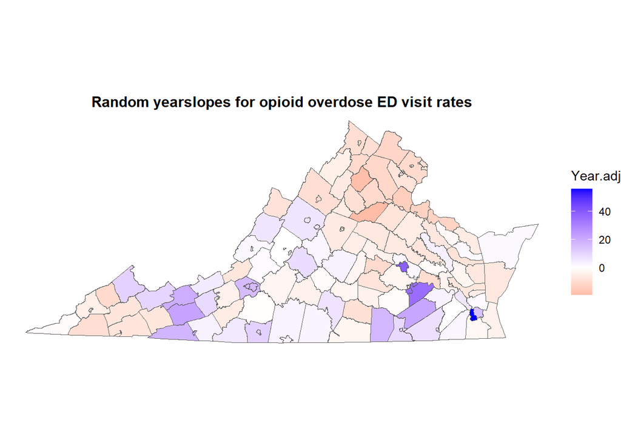

```r
ranef(model_3_rates) %>%
    rownames_to_column(var = "Locality") %>%
    left_join( # combine above with geography
        va_counties,
        by = c("Locality" = "NAMELSAD") # dplyr 1.0.8 syntax
    ) %>%
    ggplot() +
    geom_sf(aes(fill = `Year.adj`, geometry = geometry)) +
    scale_fill_gradient2( # ggplot2 3.3.5 syntax
        midpoint = 0,
        high = "blue",
        mid = "white",
        low = "red",
        na.value = "black",
        guide = "colorbar"
    ) +
    theme_void() +
    ggtitle("Random yearslopes for opioid overdose ED visit rates") +
    theme(plot.title = element_text(hjust = 0.5, size = 12, face = "bold"))
```

## “Random Growth with Time-Varying Covariates” Model

Our final model, referred to as a “Random Growth” model with time-varying covariates (TVCs), consists of main and random effects for both intercept and time as well as main effects for each of our 4 TVCs, taken from CHR data: Health Behaviors, Clinical Care, Social & Economic Factors, and Physical Environment.

```r
# # model 4 with counts
# model_4_counts <- combined_edvisits_df %>%
#     filter(Locality != "VIRGINIA") %>%
#     filter(Year %in% 2016:2021) %>% # match w/ publication
#     na.omit() %>% # 1 set of z-scores is NA
#     mutate(Year.adj = Year - 2015) %>% # for interpretation
#     lme(
#         fixed = ed_visit_count.nonheroin_opioid ~ Year.adj +
#             zHB + zCC + zSEF + zPE,
#         random = ~ Year.adj | Locality
#     )

# summary(model_4_counts)

# model 4 with rates
model_4_rates <- combined_edvisits_df %>%
    filter(Locality != "VIRGINIA") %>%
    # filter(Year %in% 2016:2021) %>% # match w/ publication
    na.omit() %>% # 1 set of z-scores is NA
    mutate(Year.adj = Year - 2015) %>% # for interpretation
    lme(
        fixed = ed_visit_rate_per_100K.combined_annual ~
            Year.adj +
            zHB + zCC + zSEF + zPE,
        random = ~ Year.adj | Locality
    )

summary(model_4_rates)
```

```
## Linear mixed-effects model fit by REML
##   Data: .
##        AIC      BIC    logLik
##   12413.63 12464.22 -6196.815
##
## Random effects:
##  Formula: ~Year.adj | Locality
##  Structure: General positive-definite, Log-Cholesky parametrization
##             StdDev   Corr
## (Intercept) 47.74182 (Intr)
## Year.adj    12.53546 -0.207
## Residual    37.91380
##
## Fixed effects:  ed_visit_rate_per_100K.combined_annual ~ Year.adj + zHB + zCC +      zSEF + zPE
##                 Value Std.Error   DF   t-value p-value
## (Intercept) 103.07386   4.66192 1034 22.109733  0.0000
## Year.adj      8.05831   1.18052 1034  6.826050  0.0000
## zHB          23.45084  19.97664 1034  1.173913  0.2407
## zCC          -2.72988  31.18611 1034 -0.087535  0.9303
## zSEF         -3.67858  16.92834 1034 -0.217303  0.8280
## zPE          22.25291  50.24513 1034  0.442887  0.6579
##  Correlation:
##          (Intr) Yer.dj zHB    zCC    zSEF
## Year.adj -0.308
## zHB       0.003  0.000
## zCC      -0.010  0.006 -0.132
## zSEF      0.007 -0.002 -0.470 -0.239
## zPE      -0.011  0.002 -0.014 -0.135 -0.015
##
## Standardized Within-Group Residuals:
##        Min         Q1        Med         Q3        Max
## -3.1711730 -0.5007790 -0.0281452  0.4500320  6.4399680
##
## Number of Observations: 1169
## Number of Groups: 130
```